# Housing and Community Development Tax Credit Program Evaluation

Myron Joel Bañez

October 16, 2020

The Department of Housing and Community Development (HCD) in Emil City has an established tax credit home repair program that has been in place for close to 20 years. HCD tries to proactively reach out to eligible homeowners ever year, the uptake of the credit is woefully inadequate. Typically only 11% of eligible homeowners they reach out to take the credit. The cost of marketing material allocation is $2,850 and credit costs are $5,000. Academic researchers in Philadelphia evaluated the program finding that houses that transacted after taking the credit, sold with a $10,000 premium, on average. Homes surrounding the repaired home see an aggregate premium of $56,000, on average. As a result this cost-benefit analysis aims to direct Emil City’s Department of Housing and Community Development to a more targeted and intentional program.

# Set Up

```r
options(scipen=10000000)
library(tidyverse)
library(kableExtra)
library(caret)
library(knitr)
library(pscl)
library(plotROC)
library(pROC)
library(lubridate)
library(gridExtra)

root.dir = "https://raw.githubusercontent.com/urbanSpatial/Public-Policy-Analytics-Landing/master/DATA/"
source("https://raw.githubusercontent.com/urbanSpatial/Public-Policy-Analytics-Landing/master/functions.r")
```

```r
palette5 <- c("#981FAC","#CB0F8B","#FF006A","#FE4C35","#FE9900")
palette4 <- c("#981FAC","#FF006A","#FE4C35","#FE9900")
palette2 <- c("#981FAC","#FF006A")


housing <- read.csv("housingSubsidy.csv")

housing <-
  housing %>%
  na.omit()
```

# Data Visualization

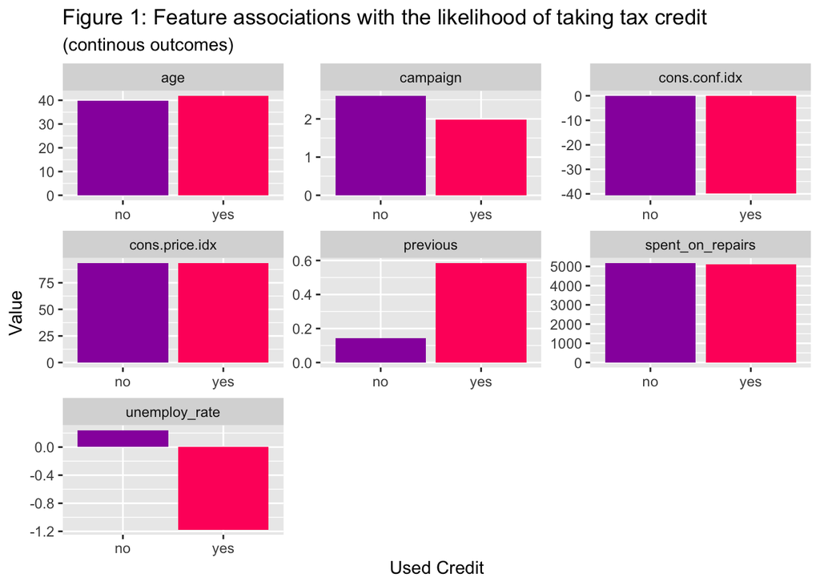

```r
housing %>%
  dplyr::select(y,unemploy_rate, spent_on_repairs, age, campaign,
                previous,cons.price.idx,cons.conf.idx) %>%
  gather(Variable, value, -y) %>%
    ggplot(aes(y, value, fill=y)) +
      geom_bar(position = "dodge", stat = "summary", fun.y = "mean") +
      facet_wrap(~Variable, scales = "free") +
      scale_fill_manual(values = palette2) +
      labs(x="Used Credit", y="Value",
           title = "Figure 1: Feature associations with the likelihood of taking tax credit",
           subtitle = "(continous outcomes)") +
      theme(legend.position = "none")
```

If an individual has a mortgage, they will not accept the tax credit compared to those without a mortgage. We can see that This is also true for individuals who pay tax in Philadelphia. If someone pays taxes in Philadelphia, they tend to use the credit more than those who do not pay taxes in Philadelphia. Lastly, if an individual has a lien on their home, they are more likely to use the tax credit more than those who do not have a lien on their home.

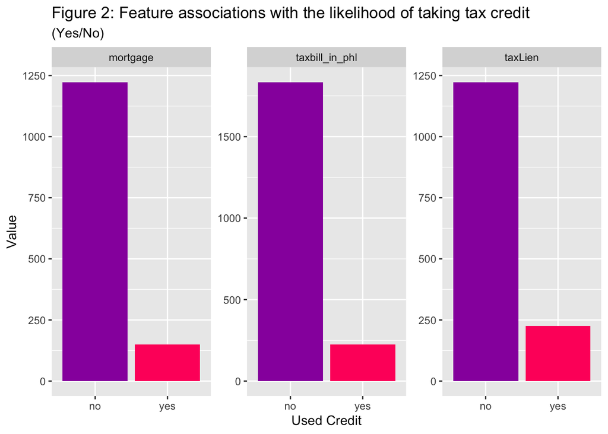

```r
# Continuous (Yes/No)
housing %>%
  dplyr::select(y,mortgage, taxbill_in_phl, taxLien) %>%
  gather(Variable, value, -y) %>%
  count(Variable, value, y) %>%
    ggplot(aes(y, n, fill=y)) +
      geom_bar(position = "dodge", stat = "summary", fun.y = "mean") +
      facet_wrap(~Variable, scales = "free") +
      scale_fill_manual(values = palette2) +
      labs(x="Used Credit", y="Value",
           title = "Figure 2: Feature associations with the likelihood of taking tax credit",
           subtitle = "(Yes/No)") +
      theme(legend.position = "none")
```

Multiple category features do not make much of a difference. However it is worth noting that those who work in administration, are married, and or were contacted on a cellphone rather than a landline, are more likely to take advantage of the tax credit.

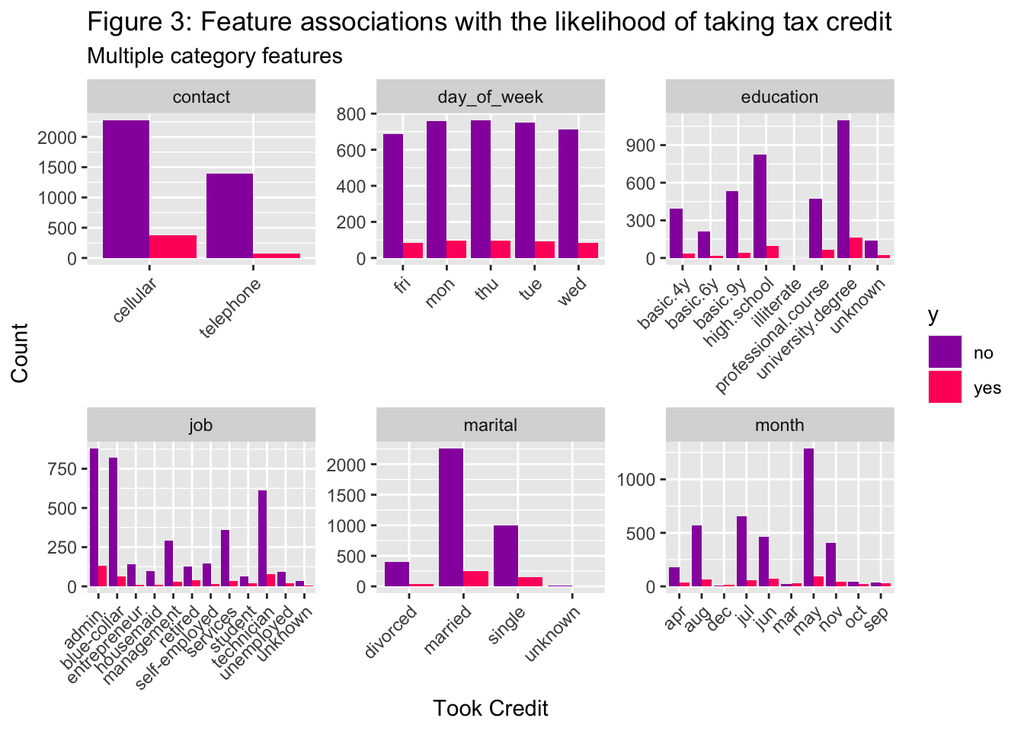

```r
# Categorical
housing %>% #make font smaller OR
  dplyr::select(y, job, marital, education, contact, month, day_of_week) %>%
  gather(Variable, value, -y) %>%
  count(Variable, value, y) %>%
  ggplot(aes(value, n, fill = y)) +
    geom_bar(position = "dodge", stat="identity") +
    facet_wrap(~Variable, scales="free") +
    scale_fill_manual(values = palette2) +
    labs(x="Took Credit", y="Count",
         title = "Figure 3: Feature associations with the likelihood of taking tax credit",
         subtitle = "Multiple category features") +
    theme(axis.text.x = element_text(angle=45, hjust=1))
```

# Feature Engineering

With knowledge of the characteristics of homeowners, we construct new datasets for season, education, the number of days since a homeowner used a previous program, employment status, and age of homeowner with the goal of improving the predicitve power of this model. - Season: months have been categorized into the season they fall into, winter, spring, summer, and fall. - Education: levels of education have been changed to simply get less than high school diploma, high school graduate, higher education, and illiterate for homeowners who do not have any formal education. - Contact: the number of days since a homeowner used a previous program were reconstructed to get weeks rather than days. - EmploymentStatus: this feature reclassifies data to determine if someone is a student, unemployed, or employed. - Age: ages have been consolidated to get generational groups such as Gen Z, Millenials, Gen X, and Boomers.

```r
# Season
housing <-
  housing %>%
  mutate(Season = case_when(
    month == "dec" |month == "jan" | month == "feb" ~ "Winter",
    month == "mar" |month == "apr" | month == "may" ~ "Spring",
    month == "jun" |month == "jul" | month == "aug" ~ "Summer",
    month == "sep" |month == "oct" | month == "nov" ~ "Fall"))

# Education
housing <-
  housing %>%
  mutate(Education = case_when(
    education == "basic.9y" |education == "basic.6y" | education == "basic.4y" ~ "Less Than HS",
    education == "high.school"  ~ "High School",
    education == "university.degree" |education == "professional.course"  ~ "Higher Education",
    education == "unknown" |education == "illiterate"  ~ "Illiterate"))

# Previous Program Contact
housing <-
  housing %>%
  mutate(Contact = case_when(pdays == 999 ~ "No Contact",
                                 pdays < 7 ~ "One week",
                                 pdays >= 7 & pdays < 21 ~ "2 Weeks",
                             pdays >= 22 & pdays < 29 ~ "3 Weeks",
                               pdays >= 30 ~ "More than 3 Weeks"))
# Employment Stauts
housing <-
  housing %>%
  mutate(EmploymentStatus = case_when(job == "student" | job == "unemployed" | job == "retired" ~ "unemployed",
                                   TRUE  ~ "employed"))
# Age Groups
housing <-
  housing %>%
  mutate(Age = case_when(
    age >= 18 & age < 22  ~ "Gen Z",
    age >= 23 & age < 38  ~ "Millenials",
    age >= 39 & age < 54  ~ "Gen X",
    TRUE ~ "Boomer"))
```

The data is then split into a 65/35 training set in order to test our model.

```r
set.seed(3456)
subsidyIndex <- createDataPartition(y = paste(housing$taxLien),  p = .65, list = FALSE, times = 1)
subsidyTrain <- housing[ subsidyIndex,]
subsidyTest  <- housing[-subsidyIndex,]
```

# Model Evaluation

We run two different regression models to get a kitchen sink and feature engineered model. The kitchen sink is essentially a model that has all of the original data while taking out the engineered features. The feature engineered model is a model that includes the features we have manipulated and extracts the original data from which it was created.

In the kitchen sink model, we get a McFadden score of .246 and a score of .223 for our feature engineered model. The McFadden score is a metric of goodness for fit. Following these regressions, the kitchen sink model has a better fit than our engineered model. In efforts to improve this model and achieve a higher McFadden score, the model has undergone a number of trials. The original kitchen sink model still received the highest McFadden score. However to test the capacity of our model, the feature engineered model is used in further analysis to test its power considering the McFadden score is not extremely different from the kitchen sink model.

```r
# Kitchen Sink
housingreg_kitchensink <- glm(y_numeric ~ .,
                  data=subsidyTrain %>% dplyr::select(-Age, -Education, -Season, -Contact, -EmploymentStatus, -X, -y),
                  family="binomial" (link="logit"))
summary(housingreg_kitchensink)
```

```
##
## Call:
## glm(formula = y_numeric ~ ., family = binomial(link = "logit"),
##     data = subsidyTrain %>% dplyr::select(-Age, -Education, -Season,
##         -Contact, -EmploymentStatus, -X, -y))
##
## Deviance Residuals:
##     Min       1Q   Median       3Q      Max
## -2.0220  -0.4092  -0.3165  -0.2386   2.9984
##
## Coefficients:
##                                   Estimate    Std. Error z value   Pr(>|z|)
## (Intercept)                  -220.64993586  129.57301818  -1.703   0.088587 .
## age                             0.01749353    0.00851481   2.054   0.039929 *
## jobblue-collar                 -0.38678642    0.28284816  -1.367   0.171478
## jobentrepreneur                -0.36832190    0.44405161  -0.829   0.406846
## jobhousemaid                   -0.69459210    0.54516984  -1.274   0.202634
## jobmanagement                  -0.67277564    0.33362700  -2.017   0.043742 *
## jobretired                     -0.14356868    0.37359257  -0.384   0.700762
## jobself-employed               -0.49658752    0.42104698  -1.179   0.238234
## jobservices                    -0.20082761    0.29678805  -0.677   0.498615
## jobstudent                     -0.27257495    0.44160300  -0.617   0.537077
## jobtechnician                   0.05247411    0.23231611   0.226   0.821300
## jobunemployed                  -0.04861986    0.41411328  -0.117   0.906537
## jobunknown                     -0.48744048    0.75337567  -0.647   0.517626
## maritalmarried                  0.30922555    0.25085001   1.233   0.217684
## maritalsingle                   0.37470117    0.28510928   1.314   0.188766
## maritalunknown                -13.06425753  438.53862981  -0.030   0.976234
## educationbasic.6y              -0.15634723    0.46642563  -0.335   0.737472
## educationbasic.9y               0.33663717    0.33524724   1.004   0.315308
## educationhigh.school            0.09953627    0.32838965   0.303   0.761810
## educationprofessional.course    0.42501405    0.35378096   1.201   0.229616
## educationuniversity.degree      0.23800631    0.33171342   0.718   0.473062
## educationunknown                0.30993409    0.42021853   0.738   0.460785
## taxLienunknown                  0.02044541    0.21875699   0.093   0.925537
## taxLienyes                    -12.07704486 1455.39763772  -0.008   0.993379
## mortgageunknown                -0.10392110    0.54708163  -0.190   0.849344
## mortgageyes                    -0.13879118    0.14504261  -0.957   0.338618
## taxbill_in_phlyes               0.21615163    0.20165145   1.072   0.283762
## contacttelephone               -1.12028746    0.30274654  -3.700   0.000215 ***
```

[output cut: 18 more lines]

```
## unemploy_rate                  -1.19279187    0.47678321  -2.502   0.012358 *
## cons.price.idx                  1.96285428    0.85611008   2.293   0.021862 *
## cons.conf.idx                   0.05154916    0.02937829   1.755   0.079316 .
## inflation_rate                  0.00564946    0.45548212   0.012   0.990104
## spent_on_repairs                0.00686037    0.01052188   0.652   0.514395
## ---
## Signif. codes:  0 '***' 0.001 '**' 0.01 '*' 0.05 '.' 0.1 ' ' 1
##
## (Dispersion parameter for binomial family taken to be 1)
##
##     Null deviance: 1915.5  on 2677  degrees of freedom
## Residual deviance: 1442.8  on 2627  degrees of freedom
## AIC: 1544.8
##
## Number of Fisher Scoring iterations: 14
```

```r
pR2(housingreg_kitchensink) #McFadden: 0.246
```

```
## fitting null model for pseudo-r2
```

```
##          llh      llhNull           G2     McFadden         r2ML         r2CU
## -721.4234621 -957.7255341  472.6041440    0.2467326    0.1617815    0.3166399
```

```r
# Engineering
housingreg_engine <- glm(y_numeric ~ .,
                  data=subsidyTrain %>% dplyr::select(-age, -month, -education,
                                                      -pdays, -job, -X, -y), #unsure about -X and -y
                  family="binomial" (link="logit"))

summary(housingreg_engine)
```

```
##
## Call:
## glm(formula = y_numeric ~ ., family = binomial(link = "logit"),
##     data = subsidyTrain %>% dplyr::select(-age, -month, -education,
##         -pdays, -job, -X, -y))
##
## Deviance Residuals:
##     Min       1Q   Median       3Q      Max
## -2.2655  -0.4147  -0.3209  -0.2592   2.9086
##
## Coefficients:
##                              Estimate Std. Error z value Pr(>|z|)
## (Intercept)                 -16.33670   81.26342  -0.201 0.840672
## maritalmarried                0.17361    0.24116   0.720 0.471585
## maritalsingle                 0.31182    0.26809   1.163 0.244782
## maritalunknown              -13.25410  443.30846  -0.030 0.976148
## taxLienunknown               -0.04701    0.21451  -0.219 0.826520
## taxLienyes                  -12.09593 1455.39760  -0.008 0.993369
## mortgageunknown               0.10019    0.50697   0.198 0.843339
## mortgageyes                  -0.11486    0.14250  -0.806 0.420226
## taxbill_in_phlyes             0.21315    0.19948   1.069 0.285283
## contacttelephone             -1.01091    0.27511  -3.675 0.000238 ***
## day_of_weekmon               -0.13795    0.22081  -0.625 0.532160
## day_of_weekthu               -0.02401    0.22051  -0.109 0.913293
## day_of_weektue               -0.08065    0.22296  -0.362 0.717553
## day_of_weekwed                0.03030    0.22673   0.134 0.893685
## campaign                     -0.08521    0.04342  -1.962 0.049709 *
## previous                      0.11903    0.20234   0.588 0.556341
## poutcomenonexistent           0.50513    0.31862   1.585 0.112889
## poutcomesuccess               1.25821    0.77414   1.625 0.104098
## unemploy_rate                -0.73591    0.25938  -2.837 0.004552 **
## cons.price.idx                0.73886    0.50084   1.475 0.140142
## cons.conf.idx                 0.01945    0.02857   0.681 0.495880
## inflation_rate                0.55890    0.43680   1.280 0.200715
## spent_on_repairs             -0.01104    0.00777  -1.420 0.155506
## SeasonSpring                  0.69801    0.30726   2.272 0.023104 *
## SeasonSummer                  0.91713    0.31466   2.915 0.003560 **
## SeasonWinter                  1.68409    0.67796   2.484 0.012990 *
## EducationHigher Education     0.24416    0.18104   1.349 0.177438
## EducationIlliterate           0.20073    0.33708   0.595 0.551511
## EducationLess Than HS        -0.07604    0.21086  -0.361 0.718384
## ContactNo Contact            -0.12539    0.72946  -0.172 0.863515
## ContactOne week               0.50306    0.53934   0.933 0.350956
## EmploymentStatusunemployed    0.12635    0.22624   0.558 0.576523
## AgeGen X                     -0.28348    0.20168  -1.406 0.159837
## AgeGen Z                     -0.37204    0.82259  -0.452 0.651071
## AgeMillenials                -0.49038    0.20374  -2.407 0.016088 *
## ---
## Signif. codes:  0 '***' 0.001 '**' 0.01 '*' 0.05 '.' 0.1 ' ' 1
##
## (Dispersion parameter for binomial family taken to be 1)
##
##     Null deviance: 1915.5  on 2677  degrees of freedom
## Residual deviance: 1487.2  on 2643  degrees of freedom
## AIC: 1557.2
##
## Number of Fisher Scoring iterations: 14
```

```r
pR2(housingreg_engine) #McFadden: 0.223
```

```
## fitting null model for pseudo-r2
```

```
##          llh      llhNull           G2     McFadden         r2ML         r2CU
## -743.6094252 -957.7255341  428.2322179    0.2235673    0.1477774    0.2892308
```

Visually we now can begin comparing the predictions of taking the tax credit. A negative or 0 value means that they did not use the tax credit, while a positive or 1 value means that they did use the tax credit. Strong models will have a peak closer to 0 for the negatives (no tax credit), and a peak closer to 1 for the positives (tax credit). In figure 4 we can see that our model is better at prediciting the negatives rather than the positives. However it is worth mentioning that although the peak is closer to 0, the positive values still have a considerably thick density closer to the 1

```r
testProbs <- data.frame(Outcome = as.factor(subsidyTest$y_numeric),
                        Probs = predict(housingreg_engine, subsidyTest, type= "response"))

head(testProbs)
```

```
##    Outcome      Probs
## 5        0 0.05598599
## 6        0 0.30434771
## 11       0 0.06039123
## 13       0 0.04100150
## 16       0 0.09189985
## 18       0 0.02062162
```

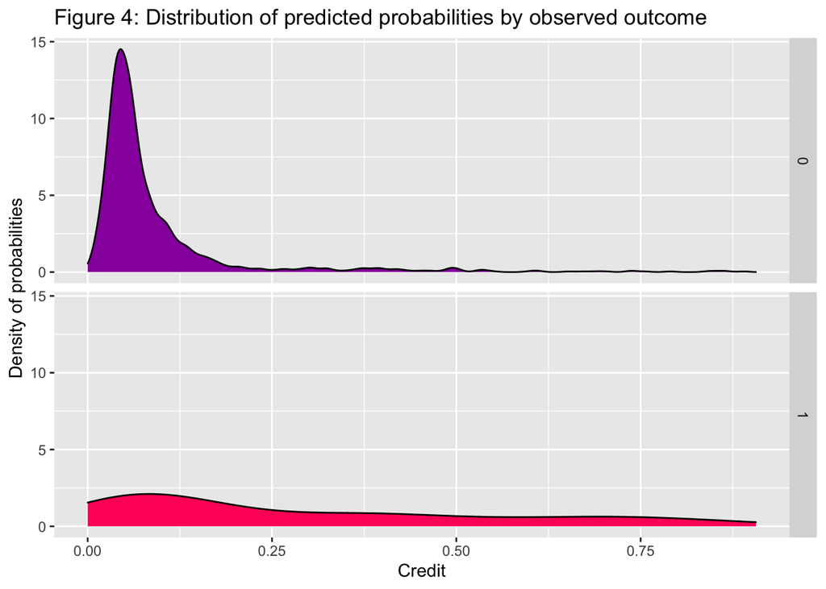

```r
testProbs <-
  testProbs %>%
  na.omit()

ggplot(testProbs, aes(x = Probs, fill = as.factor(Outcome))) +
  geom_density() +
  facet_grid(Outcome ~ .) +
  scale_fill_manual(values = palette2) +
  labs(x = "Credit", y = "Density of probabilities",
       title = "Figure 4: Distribution of predicted probabilities by observed outcome") +
  theme(strip.text.x = element_text(size = 18),
        legend.position = "none")
```

## Confusion Matrix

The Confusion Matrix shows the number of observed instances of using the tax credit that are predicted as such. Each entry in the matrix provides a different comparison between observed and predicted, given the 50% threshold.

```r
testProbs <-
  testProbs %>%
  mutate(predOutcome  = as.factor(ifelse(testProbs$Probs > 0.5 , 1, 0)))

caret::confusionMatrix(testProbs$predOutcome, testProbs$Outcome,
                       positive = "1")
```

```
## Confusion Matrix and Statistics
##
##           Reference
## Prediction    0    1
##          0 1277  107
##          1   22   34
##
##                Accuracy : 0.9104
##                  95% CI : (0.8945, 0.9247)
##     No Information Rate : 0.9021
##     P-Value [Acc > NIR] : 0.1538
##
##                   Kappa : 0.3066
##
##  Mcnemar's Test P-Value : 0.0000000000001406
##
##             Sensitivity : 0.24113
##             Specificity : 0.98306
##          Pos Pred Value : 0.60714
##          Neg Pred Value : 0.92269
##              Prevalence : 0.09792
##          Detection Rate : 0.02361
##    Detection Prevalence : 0.03889
##       Balanced Accuracy : 0.61210
##
##        'Positive' Class : 1
##
```

## ROC Curve

The next goodness of fit metric used is the ROC Curve. ROC is useful because it visualizes the trade-offs for two important confusion metrics, while also providing a single goodness of fit indicator. The y-axis of the ROC curve shows the rate of true positives for each threshold from 0.01 to 1. The x-axis shows the rate of false positives for each threshold. A good indicator is using another metric such as the area under curve or AUC. A strong model will be one that is under the orange curve and above the line, or a value between 1 and 0.5. The AUC curve for our model is .75, proposing that we have a strong model with the feature engineered variables.

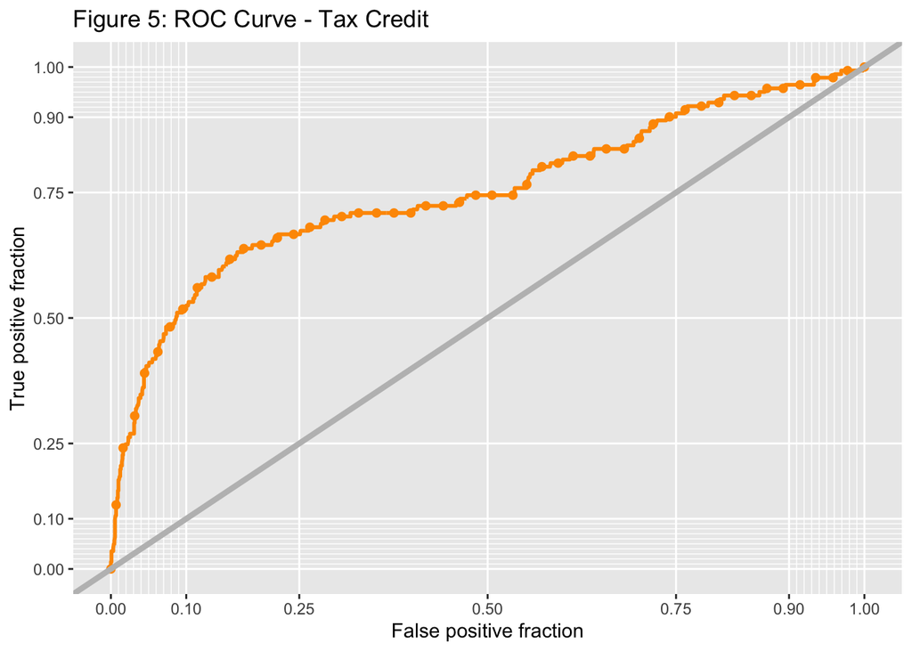

```r
ggplot(testProbs, aes(d = as.numeric(testProbs$Outcome), m = Probs)) +
  geom_roc(n.cuts = 50, labels = FALSE, colour = "#FE9900") +
  style_roc(theme = theme_grey) +
  geom_abline(slope = 1, intercept = 0, size = 1.5, color = 'grey') +
  labs(title = "Figure 5: ROC Curve - Tax Credit")
```

```r
pROC::auc(testProbs$Outcome, testProbs$Probs) # AUC: .75
```

```
## Area under the curve: 0.7504
```

## Cross Validation

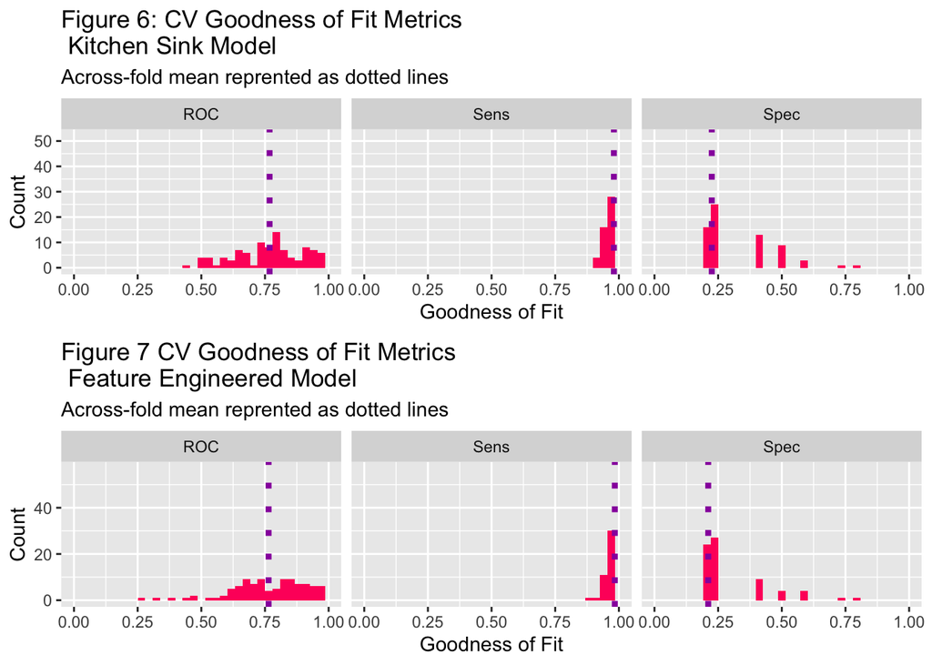

```r
ctrl <- trainControl(method = "cv", number = 100, classProbs=TRUE, summaryFunction=twoClassSummary)


cvFit_engine <- train(y ~ .,
                  data = housing %>%
                    na.omit() %>%
                    dplyr::select(-age, -month, -education, -pdays, -job, -X, -y_numeric),
                method="glm", family="binomial",
                metric="ROC", trControl = ctrl)

cvFit_kitchensink <- train(y ~ .,
                  data = housing %>%
                    dplyr::select(-Age, -Education, -Season, -Contact, -EmploymentStatus, -X, -y_numeric),
                method="glm", family="binomial",
                metric="ROC", trControl = ctrl)

grid.arrange(ncol = 1,

  dplyr::select(cvFit_kitchensink$resample, -Resample) %>%
  gather(metric, value) %>%
  left_join(gather(cvFit_kitchensink$results[2:4], metric, mean)) %>%
  ggplot(aes(value)) +
  geom_histogram(bins=35, fill = "#FF006A") +
  facet_wrap(~metric) +
  geom_vline(aes(xintercept = mean), colour = "#981FAC", linetype = 3, size = 1.5) +
  scale_x_continuous(limits = c(0, 1)) +
  labs(x="Goodness of Fit", y="Count", title="Figure 6: CV Goodness of Fit Metrics \n Kitchen Sink Model",
       subtitle = "Across-fold mean reprented as dotted lines"),


  dplyr::select(cvFit_engine$resample, -Resample) %>%
  gather(metric, value) %>%
  left_join(gather(cvFit_engine$results[2:4], metric, mean)) %>%
  ggplot(aes(value)) +
  geom_histogram(bins=35, fill = "#FF006A") +
  facet_wrap(~metric) +
  geom_vline(aes(xintercept = mean), colour = "#981FAC", linetype = 3, size = 1.5) +
  scale_x_continuous(limits = c(0, 1)) +
  labs(x="Goodness of Fit", y="Count", title="Figure 7 CV Goodness of Fit Metrics \n Feature Engineered Model",
       subtitle = "Across-fold mean reprented as dotted lines"))
```

# Cost-Benefit Analysis

As the final step, we want to create a cost-benefit analysis that allows us to optimize our resource allocation and ensure we are impacting the most amount of people with the limited resources we have for a more directed campaign. For this analysis, we are looking at the calculations from the standpoint of the Department of Housing and Community Development.

In creating the cost benefit calculation, we have the following assumptions:

- Marketing resources: $2,850
- Credit costs: $5,000.
- Houses that transacted after taking the credit: sold with a $10,000 premium.
- 25% of eligible homeowners will take the credit.

With these assumptions in mind, we will now formulate mathematical equations to get our calculations:

- True Negative: Count * 0. We predict they would not take the credit, and as a result no marketing or credit was allocated.
- True Positive: (Count * -2850) - ((Count * .25) * -5000). In breaking this down, we allocate marketing resources to homeowners, so we will multiply the number of homeowners by negative 2,850. Next we will take 25% of the homeowners by doing (Count * .25) and multiplying this by negative 5,000, because 25% of homeowners took the credit.
- False Negative: Count * 0. Although we predict homeowners would not take credit but they did, we will zero this out because we are analyzing the impact on of the marketing campaign.
- False Positive: Count * -2850. Marketing resources were allocated but no credit.

```r
cost_benefit_table <- # Check math
   testProbs %>%
      count(predOutcome, Outcome) %>%
      summarize(True_Negative = sum(n[predOutcome==0 & Outcome==0]),
                True_Positive = sum(n[predOutcome==1 & Outcome==1]),
                False_Negative = sum(n[predOutcome==0 & Outcome==1]),
                False_Positive = sum(n[predOutcome==1 & Outcome==0])) %>%
       gather(Variable, Count) %>%
       mutate(Revenue =
               case_when(Variable == "True_Negative"  ~ Count * 0,
                         Variable == "True_Positive"  ~ ((Count * -2850) - ((Count * .25) * -5000)),
                         Variable == "False_Negative" ~ Count * 0,
                         Variable == "False_Positive" ~ (Count * -2850))) %>%
    bind_cols(data.frame(Description = c(
              "Predicted correctly homeowner would not take the credit, no marketing resources were allocated, and no
              credit was allocated.",
              "Predicted correctly homeowner would take the credit; allocated the marketing resources, and 25% took
              the credit.", #25% take the 5000
              "We predicted that a homeowner would not take the credit but they did.",
              "Predicted incorrectly homeowner would take the credit; allocated marketing resources; no credit
              allocated.")))

kable(cost_benefit_table,
       caption = "Figure 8: Cost/Benefit Table") %>% kable_styling()
```

Figure 8: Cost/Benefit Table

| Variable | Count | Revenue | Description |
| --- | --- | --- | --- |
| True_Negative | 1277 | 0 | Predicted correctly homeowner would not take the credit, no marketing resources were allocated, and no credit was allocated. |
| True_Positive | 34 | -54400 | Predicted correctly homeowner would take the credit; allocated the marketing resources, and 25% took the credit. |
| False_Negative | 107 | 0 | We predicted that a homeowner would not take the credit but they did. |
| False_Positive | 22 | -62700 | Predicted incorrectly homeowner would take the credit; allocated marketing resources; no credit allocated. |

For our analysis, revenue of $0 is essentially good as it means that we as a department are not losing money. However we lose a great sum of money with our true positives and false positives.

```r
iterateThresholds <- function(data) {
  x = .01
  all_prediction <- data.frame()
  while (x <= 1) {

  this_prediction <-
      testProbs %>%
      mutate(predOutcome = ifelse(Probs > x, 1, 0)) %>%
      count(predOutcome, Outcome) %>%
      summarize(True_Negative = sum(n[predOutcome==0 & Outcome==0]),
                True_Positive = sum(n[predOutcome==1 & Outcome==1]),
                False_Negative = sum(n[predOutcome==0 & Outcome==1]),
                False_Positive = sum(n[predOutcome==1 & Outcome==0])) %>%
     gather(Variable, Count) %>%
     mutate(Revenue =
               ifelse(Variable == "True_Negative", (Count * 0),
               ifelse(Variable == "True_Positive", ((Count * -2850) - ((Count * .25) * -5000)),
               ifelse(Variable == "False_Negative", (Count * 0),
               ifelse(Variable == "False_Positive", (Count * -2850), 0
                      )
               )
               )
               ),
            Threshold = x)

  all_prediction <- rbind(all_prediction, this_prediction)
  x <- x + .01
  }
return(all_prediction)
}
```

Using an iterate threshold, we are able to achieve a confusion matrix that visualizes the venue by threshold as seen in figure 9. Approximately around threshold 0.25, the revenue begins to normalize and flattens out. It is important to note that most money was spent on the false positive groups, and false negative and true negative are zero-d out. A sum of money is also spent on true positives, however their costs are offset by the impact of the tax credit program.

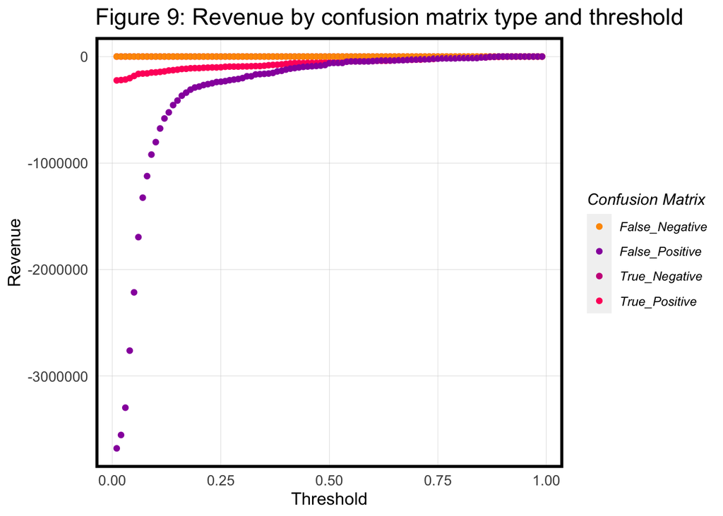

```r
whichThreshold <- iterateThresholds(testProbs)

whichThreshold_revenue <-
whichThreshold %>%
    group_by(Threshold) %>%
    summarize(Revenue = sum(Revenue))

whichThreshold %>%
  ggplot(.,aes(Threshold, Revenue, colour = Variable)) +
  geom_point() +
  scale_colour_manual(values = palette5[c(5, 1:3)]) +
  labs(title = "Figure 9: Revenue by confusion matrix type and threshold",
       y = "Revenue") +
  plotTheme() +
  guides(colour=guide_legend(title = "Confusion Matrix"))
```

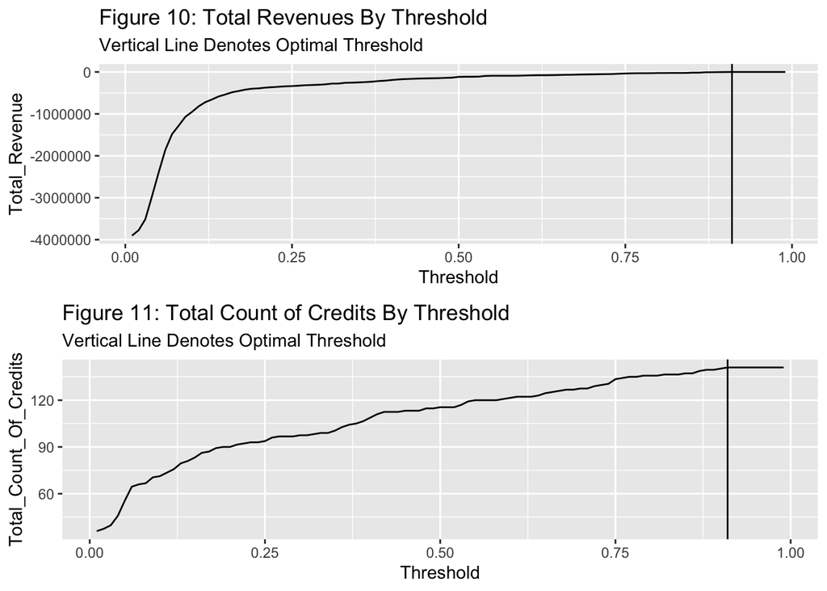

```r
whichThreshold_revenue <-
  whichThreshold %>%
    mutate(TookCredit = ifelse(Variable == "True_Positive", (Count * .25),
                         ifelse(Variable == "False_Negative", Count, 0))) %>%
  group_by(Threshold) %>%
    summarize(Total_Revenue = sum(Revenue),
              Total_Count_Of_Credits = sum(TookCredit))

# Revenue
grid.arrange(ncol = 1,
ggplot(whichThreshold_revenue)+
  geom_line(aes(x = Threshold, y = Total_Revenue))+
  geom_vline(xintercept =  pull(arrange(whichThreshold_revenue, -Total_Revenue)[1,1]))+
    labs(title = "Figure 10: Total Revenues By Threshold",
         subtitle = "Vertical Line Denotes Optimal Threshold"),
# Credits
ggplot(whichThreshold_revenue)+
  geom_line(aes(x = Threshold, y = Total_Count_Of_Credits))+
  geom_vline(xintercept =  pull(arrange(whichThreshold_revenue, -Total_Count_Of_Credits)[1,1]))+
    labs(title = "Figure 11: Total Count of Credits By Threshold",
         subtitle = "Vertical Line Denotes Optimal Threshold"))
```

```r
optimalthreshold <-
  whichThreshold_revenue %>%
  dplyr::select(Threshold, Total_Revenue, Total_Count_Of_Credits)

optimalthreshold_table <-
  whichThreshold_revenue %>%
  dplyr::select(Threshold, Total_Revenue, Total_Count_Of_Credits)

optimalthreshold_table <-
  optimalthreshold %>%
  filter(row(optimalthreshold) == c(25, 50))

kable(optimalthreshold_table,
       caption = "Cost/Benefit Table") %>% kable_styling()
```

Cost/Benefit Table

| Threshold | Total_Revenue | Total_Count_Of_Credits |
| --- | --- | --- |
| 0.25 | -337350 | 93.75 |
| 0.50 | -117100 | 115.50 |

# Conclusion